# Landmarks and coarse-graining

**Tip**

How to use a coarse-grained subsample of target pixels - or “landmarks” - to increase computational performance with minimal loss in accuracy.

In this notebook we demonstrate the use of landmarks with the `coarse_graining` function to reduce the computational demands in ConScape, see main text of details and discussion.

# Data import

See notebook getting started for a ‘basic workflow’ to learn about data import and the creation of a ConScape `Grid`:

```
"/home/runner/work/ConScape.jl/ConScape.jl/src/../data"
```

```
┌ 117×87 RasterStack ┐
├────────────────────┴─────────────────────────────────────────────────── dims ┐
  ↓ X Projected{Float64} 110650.0:1000.0:226650.0 ForwardOrdered Regular Intervals{Start},
  → Y Projected{Float64} 6.98175e6:-1000.0:6.89575e6 ReverseOrdered Regular Intervals{Start}
├────────────────────────────────────────────────────────────────────── layers ┤
  :steplikelihood eltype: Float64 dims: X, Y size: 117×87
  :quality        eltype: Float64 dims: X, Y size: 117×87
├────────────────────────────────────────────────────────────────────── raster ┤
  missingval: NaN
  extent: Extent(X = (110650.0, 227650.0), Y = (6.89575e6, 6.98275e6))
  crs:
└──────────────────────────────────────────────────────────────────────────────┘
```

# Coarse graining

Internally, target qualities can be represented by a sparse matrix. This means that habitat of quality zero is not explicitly stored in the matrix, which reduces the memory footprint in case of matrices with many zeros.

We can further increase the sparseness of this matrix to reduce the computational requirements in terms of processing time.

`ConScape.Problem` has a `grain` argument to control the coase of aggregation. It does so by summing the target qualities of all pixels and assigning this value to the center pixel, while setting all other cells to zero. When running `init` or `solve` on a `MovementMode` like `RSP`, `grain` can be passed as a keyword, that will be used to construct a `Problem` internally.

The idea is thus to connect pixels from a higher resolution source map to a lower resolution target map. The benefit of this approach compared to, for instance, using lower resolution maps in general is that movement paths are still represented with a high resolution.

The main assumption this is that all high-resolution pixels within a coarse pixel are equally well connected to the source pixel as the high-resolution pixel at the center of the coarse pixel. This assumption will be more difficult to meet with increasing number of pixels aggregated and with increasing heterogeneity in the landscape.

We will now investigate how the estimation of the amount of connected habitat and the movement flow are affected by this coarse graining of the target pixels.

## Connected habitat and coarse graining

We compute the amount of connected habitat or functionality for each pixel using the expected cost distance and an exponential decay for both the high-resolution and low-resolution target qualities:

```
┌ 117×87 Raster{Float64, 2} FunctionalHabitat ┐
├─────────────────────────────────────────────┴────────────────────────── dims ┐
  ↓ X Projected{Float64} 110650.0:1000.0:226650.0 ForwardOrdered Regular Intervals{Start},
  → Y Projected{Float64} 6.98175e6:-1000.0:6.89575e6 ReverseOrdered Regular Intervals{Start}
├────────────────────────────────────────────────────────────────────── raster ┤
  missingval: NaN
  extent: Extent(X = (110650.0, 227650.0), Y = (6.89575e6, 6.98275e6))
  crs:
└──────────────────────────────────────────────────────────────────────────────┘
      ↓ →    6.98175e6    6.98075e6    6.97975e6  …    6.89675e6    6.89575e6
 110650.0  NaN          NaN          NaN             NaN          NaN
 111650.0  NaN          NaN          NaN             NaN          NaN
 112650.0  NaN          NaN          NaN             NaN          NaN
 113650.0  NaN          NaN          NaN             NaN          NaN
      ⋮                                           ⋱
 223650.0  NaN          NaN          NaN             NaN          NaN
 224650.0  NaN          NaN          NaN          …  NaN          NaN
 225650.0  NaN          NaN          NaN             NaN          NaN
 226650.0  NaN          NaN          NaN             NaN          NaN
```

```
GLMakie.Screen(...)
```

Hence, the correlation between these values is:

```
0.9995672056716131
```

Clearly, the estimation of the ranking of source pixels based upon their functional connectivity to target pixels is relatively little affected by the aggregation of these target pixels.

When we look at the change in the amount of connected habitat in the landscape:

```
0.9318905359330013
```

There is some under-estimation, however, note that we used a substantial level of coarse graining (i.e. $20 \times 20$). We now investigate how the accuracy changes for different levels of coarse graining.

Compute both the correlation between pixel-level and landscape-level amount of connnected habitat over a range of aggregation levels (from 1, no aggregation, to 50):

```
9-element Vector{Tuple{Float64, Raster{Float64, 2, Tuple{X{Projected{Float64, StepRangeLen{Float64, Base.TwicePrecision{Float64}, Base.TwicePrecision{Float64}, Int64}, DimensionalData.Dimensions.Lookups.ForwardOrdered, DimensionalData.Dimensions.Lookups.Regular{Float64}, DimensionalData.Dimensions.L…
 (5.195568226, [NaN NaN … NaN NaN; NaN NaN … NaN NaN; … ; NaN NaN … NaN NaN; NaN NaN … NaN NaN])
 (1.320822297, [NaN NaN … NaN NaN; NaN NaN … NaN NaN; … ; NaN NaN … NaN NaN; NaN NaN … NaN NaN])
 (0.710448657, [NaN NaN … NaN NaN; NaN NaN … NaN NaN; … ; NaN NaN … NaN NaN; NaN NaN … NaN NaN])
 (0.219975591, [NaN NaN … NaN NaN; NaN NaN … NaN NaN; … ; NaN NaN … NaN NaN; NaN NaN … NaN NaN])
 (0.122468346, [NaN NaN … NaN NaN; NaN NaN … NaN NaN; … ; NaN NaN … NaN NaN; NaN NaN … NaN NaN])
 (0.067739918, [NaN NaN … NaN NaN; NaN NaN … NaN NaN; … ; NaN NaN … NaN NaN; NaN NaN … NaN NaN])
 (0.042670915, [NaN NaN … NaN NaN; NaN NaN … NaN NaN; … ; NaN NaN … NaN NaN; NaN NaN … NaN NaN])
 (0.145587764, [NaN NaN … NaN NaN; NaN NaN … NaN NaN; … ; NaN NaN … NaN NaN; NaN NaN … NaN NaN])
 (0.019801875, [NaN NaN … NaN NaN; NaN NaN … NaN NaN; … ; NaN NaN … NaN NaN; NaN NaN … NaN NaN])
```

Calculate sums and correlations with non-aggregated outputs:

```
9-element Vector{Float64}:
 1.0
 0.9999900102671109
 0.9999999795566323
 0.9999999194964372
 0.9999995243890809
 0.9999938435587693
 0.9998193628225124
 0.9995672056716131
 0.9855954466632688
```

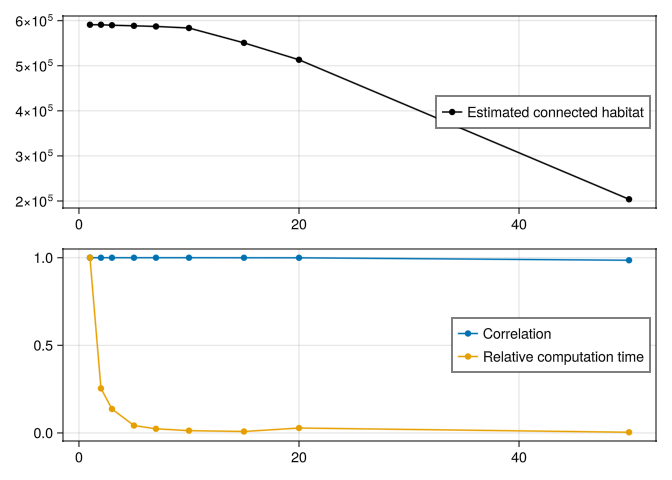

The correlation between the full and landmark-based habitat functionality in function of the level of ‘coarse graining’.

The ranking of source pixels based on their functional connectivity to high-quality target pixels, is hardly affected by aggregation. Aggregating less than $10 \times 10$ pixels results in a virtual identical ranking, whereas even sever levels of aggregation ($50 \times 50$) still result in a correlation above $0.98$.

However the loss in accuracy is a bit more pronounced for the amount of connnected habitat.

We can see in our example that aggregating less than 10 pixels will result in less than 1% drop in estimated amount of connected habitat, but increasing the level of aggregation will result in an accelerating underestimation of the actual amount of connected habitat.

# Betweenness and coarse graining

We compute the betweenness or movement flow for each pixel for both the high-resolution and low-resolution ($20 \times 20$) target qualities, first for the quality weighted version:

```
┌ 117×87 Raster{Float64, 2} Betweenness_QualityWeighted ┐
├───────────────────────────────────────────────────────┴──────────────── dims ┐
  ↓ X Projected{Float64} 110650.0:1000.0:226650.0 ForwardOrdered Regular Intervals{Start},
  → Y Projected{Float64} 6.98175e6:-1000.0:6.89575e6 ReverseOrdered Regular Intervals{Start}
├────────────────────────────────────────────────────────────────────── raster ┤
  missingval: NaN
  extent: Extent(X = (110650.0, 227650.0), Y = (6.89575e6, 6.98275e6))
  crs:
└──────────────────────────────────────────────────────────────────────────────┘
      ↓ →    6.98175e6    6.98075e6    6.97975e6  …    6.89675e6    6.89575e6
 110650.0  NaN          NaN          NaN             NaN          NaN
 111650.0  NaN          NaN          NaN             NaN          NaN
 112650.0  NaN          NaN          NaN             NaN          NaN
 113650.0  NaN          NaN          NaN             NaN          NaN
      ⋮                                           ⋱
 223650.0  NaN          NaN          NaN             NaN          NaN
 224650.0  NaN          NaN          NaN          …  NaN          NaN
 225650.0  NaN          NaN          NaN             NaN          NaN
 226650.0  NaN          NaN          NaN             NaN          NaN
```

```
0.931064194802204
```

```
GLMakie.Screen(...)
```

We found similar results for the quality and proximity weighted version of the betweenness:

```
┌ 117×87 Raster{Float64, 2} Betweenness_QualityAndProximityWeighted ┐
├───────────────────────────────────────────────────────────────────┴──── dims ┐
  ↓ X Projected{Float64} 110650.0:1000.0:226650.0 ForwardOrdered Regular Intervals{Start},
  → Y Projected{Float64} 6.98175e6:-1000.0:6.89575e6 ReverseOrdered Regular Intervals{Start}
├────────────────────────────────────────────────────────────────────── raster ┤
  missingval: NaN
  extent: Extent(X = (110650.0, 227650.0), Y = (6.89575e6, 6.98275e6))
  crs:
└──────────────────────────────────────────────────────────────────────────────┘
      ↓ →    6.98175e6    6.98075e6    6.97975e6  …    6.89675e6    6.89575e6
 110650.0  NaN          NaN          NaN             NaN          NaN
 111650.0  NaN          NaN          NaN             NaN          NaN
 112650.0  NaN          NaN          NaN             NaN          NaN
 113650.0  NaN          NaN          NaN             NaN          NaN
      ⋮                                           ⋱
 223650.0  NaN          NaN          NaN             NaN          NaN
 224650.0  NaN          NaN          NaN          …  NaN          NaN
 225650.0  NaN          NaN          NaN             NaN          NaN
 226650.0  NaN          NaN          NaN             NaN          NaN
```

```
0.9227035681791327
```

```
GLMakie.Screen(...)
```

As commented above, a $20 \times 20$ aggregation of pixels is quite a high level of compression. Let’s now see how the accuracy changes with changing levels of aggregation.

[output not shown]

```
9-element Vector{Float64}:
 1.0
 0.9996610364273975
 0.9997591123659272
 0.9988431734897526
 0.9957190189236119
 0.9873056321836667
 0.9632249245753121
 0.9227035681791327
 0.3279181494782633
```

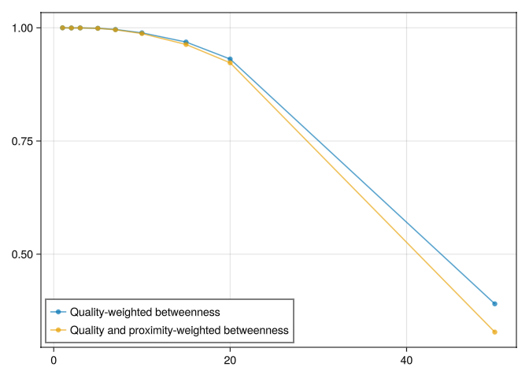

The correlation between the full and landmark-based betweenness in function of the level of ‘coarse graining’.

We see that the level of accuracy is good for levels of aggregation below 10, but starts to drop off rather rapidly above this.

## Summary

The keyword `grain` in useful tool to reduce the computational demands of dealing with high-resolution landscapes by connecting a high-resolution map of source pixels to a lower resolution map of target pixels.

Unfortunately, the computational benefits come at the cost of a loss in accuracy. We found for our example that aggregation levels below 10 led to a substantial benefit in terms of computation with minimal loss in accuracy. We suggest that researchers explore how the accuracy changes in their landscape with changing levels of aggregation.

Windowing the landscape is an alternative approach to reduce computational demands, see windowing.